# Introduction to functional data analysis (FDA)

## 1. Canadian Weather dataset

We consider the *Canadian Weather dataset* that is provided by the functional data analysis package `fda`.

This dataset provides data about daily temperature and precipitation at 35 different locations in Canada, averaged over 1960 to 1994. In particular, the R object `CanadianWeather` is a list with the following components:

- `dailyAv`: three dimensional array with dimension 365x35x3, with daily data collected at 35 different weather stations in Canada. The third dimension permits to access the following 3 variables:
  1. `Temperature.C`: daily temperature in Celsius, averaged over 1960 to 1994;
  2. `Precipitation.mm`: daily rainfall in mm, averaged over 1960 to 1994 (rounded to 0.1 mm);
  3. `log10precip`: base 10 logarithm of `Precipitation.mm` (after replacing 27 zeros by 0.05 mm);
- `place`: names of the 35 weather stations in Canada;
- `province`: names of the Canadian provinces of the 35 weather stations;
- `coordinates`: matrix with latitude (`N.latitude`) and longitude (`W.longitude`) of each of the 35 ewather stations;
- `region`: climate zone of the 35 weather stations. Possible values: `Atlantic`, `Pacific`, `Continental` and `Artic`;
- `monthlyTemp`: matrix of dimension 12x35, with montly average temperatures;
- `monthlyPrecip`: matrix of dimension 12x35, with montly average precipitation;
- `geogindex`: order the weather stations from East to West to North.

```r
require(fda)
data("CanadianWeather")
names(CanadianWeather)
```

```
[1] "dailyAv"       "place"         "province"      "coordinates"   "region"        "monthlyTemp"   "monthlyPrecip" "geogindex"
```

We are interested in studying the annual pattern of temperature in the different Canadian locations.

Let’s extract from the list `CanadianWeather` only the variable of interest. Remember that we can access each component of a list using the `$` sign, while to access part of an array we can use squared parenteses `[ ]`. In the following code, we first access the three dimensional array `dailyAv` using `CanadianWeather$dailyAv`, then we extract the part of the array corresponding to the variable `Temperature.C` using `[ , , 'Temperature.C']` (note that the first dimension of the array corresponds to the 365 days, the second dimension to the 35 weather stations, and the third to the 3 variables):

```r
temp = CanadianWeather$dailyAv[ , , 'Temperature.C']
dim(temp)
```

```
[1] 365  35
```

`temp` is a matix (a two dimensional array) with a row for each day and a column for each of the 35 weather stations. Let’s print a small part of it:

```r
temp[1:10, 1:10]
```

```
      St. Johns Halifax Sydney Yarmouth Charlottvl Fredericton Scheffervll Arvida Bagottville Quebec
jan01      -3.6    -4.4   -3.8     -1.4       -5.8        -7.9       -22.5  -14.1       -14.6  -10.8
jan02      -3.1    -4.2   -3.5     -1.6       -5.6        -7.5       -23.0  -14.4       -14.7  -11.4
jan03      -3.4    -5.3   -4.6     -2.5       -7.3        -9.3       -23.0  -15.0       -15.5  -12.5
jan04      -4.4    -5.4   -5.0     -2.3       -7.0        -8.7       -21.8  -14.3       -14.3  -11.2
jan05      -2.9    -5.6   -4.1     -2.4       -6.7        -9.1       -23.5  -16.2       -15.8  -12.0
jan06      -4.5    -7.1   -6.1     -3.7       -8.9       -10.9       -24.4  -16.3       -16.9  -13.2
jan07      -5.5    -5.8   -5.5     -2.6       -7.5        -9.6       -25.3  -14.6       -15.5  -11.9
jan08      -3.1    -5.4   -3.9     -2.6       -6.9        -9.5       -24.9  -15.8       -16.6  -12.9
jan09      -4.0    -6.8   -5.4     -4.1       -8.9       -10.8       -23.5  -16.8       -17.4  -13.8
jan10      -5.0    -6.4   -5.9     -3.8       -8.8       -10.7       -24.6  -16.3       -17.7  -14.0
```

We need to create a vector with the time points $t_1,\dots,t_{365}$ corresponding to the daily measurements. Since the range for the time is the interval $[0,365]$ and we have 365 measurements, we can put the time points half-way through a day:

```r
daytime = (1:365) - 0.5
```

Let’s now visualize the data, plotting points for each weather station in different colors. In order to do this we can employ the function `matplot`, that plots all the columns of a matrix; this function wants as input the vector of time points and the matrix with the measurements. In order to plot a circle for each column, we use the argument `pch = 1` (the default is to plot a number):

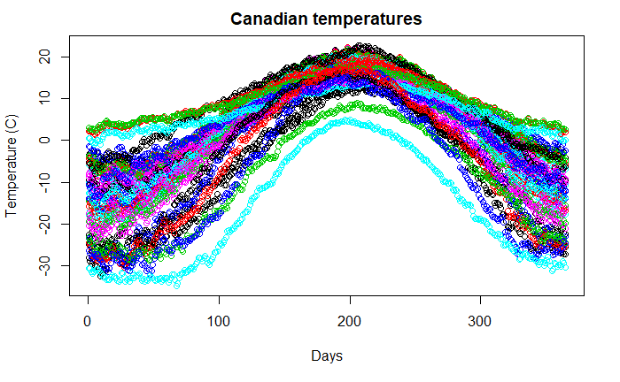

```r
matplot(daytime, temp, pch = 1, xlab = 'Days', ylab = 'Temperature (C)', main = 'Canadian temperatures')
```

We can observe from this plot that the pattern for all locations is periodic: at the beginning of the year we have the lowest temperatures, then the temperature increase to reach a peak in the middle of the year (summer), then they go down again. We can also see that, although the general pattern is the same for all locations, there is a lot of variability between them: some locations show very strong differences between winter and summer, while others have flatter patterns.

We can also produce the same plot with different colors corresponding to the different climate zones of the 35 locations. Climate zones are provided by the element `region` in the list `CanadianWeather` and we can setup the colors using the argument `col`:

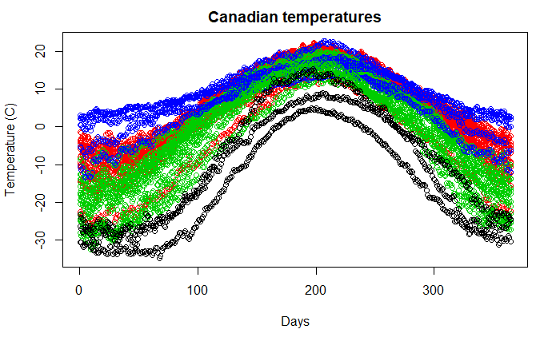

```r
col_regions = as.factor(CanadianWeather$region)
matplot(daytime, temp, pch = 1, col = col_regions, xlab = 'Days', ylab = 'Temperature (C)', main = 'Canadian temperatures')
```

We can observe that the annual temperature pattern of locations within the same climate zone are indeed more similar!

Let’s now visualize only the data of one location… let’s select Québec, that is in column 10!

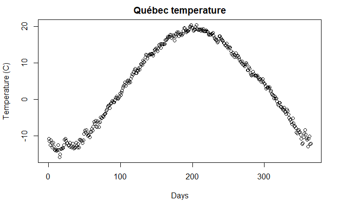

```r
temp_quebec = temp[ ,10]
plot(daytime, temp_quebec, xlab = 'Days', ylab = 'Temperature (C)', main = 'Québec temperature')
```

The pattern is the expected one. we see that the lowest average temperatures are in first 50 days of the year and in the very last, January and February (this matches my experience in Québec!). We can see that we don’t have much noise in the data (this is because they are average temperatures over many years), but still we don’t have a **functional datum**. The points in the plot are our noisy measurements $y_1,\dots,y_{365}$ at resolution of one day, i.e. at $t_1=1,\dots,t_{365}=365$:
$$y_j = x(t_j) + \varepsilon_j$$
We need to compute the functional datum (curve) $x(t)$ from the data. This will be defined over all possible times $t \in [0,365]$.

## 2. Basis function approach

In order to compute curves from raw data we first define a family of **basis functions** $\phi_1(t),\dots,\phi_K(t)$, then consider the basis expansion of the curve $x(t)=\sum_{k=1}^K c_k \phi_k(t)$, and finally estimate the coefficients $c_1,\dots,c_K$ using smoothing techniques.

Whatever the choice of basis function, we need to define the range (i.e. the lower and the upper limits) for the values of $t$ where they will be defined. In our case we have $t \in [0,365]$:

```r
range_day = c(0,365)
range_day
```

```
[1]   0 365
```

We consider two types of basis functions, Fourier basis and spline basis, but other choices are possible.

### Fourier basis

**Fourier basis** are useful to model a periodic curve $x(t)$, hence they should be a good choice for our temperature data. In order to create Fourier basis functions we employ the function `create.fourier.basis` from the package `fda`. This function wants as input the range for the values of $t$, the number of basis functions $K$ (argument `nbasis`, that should be an odd number in order to preserve the pairing between sine and cosine) and the period $T$ of the curve (the default is the total length of the range for the values of $t$).

Let’s start creating a very simple Fourier basis with $K=3$ functions: $\phi_1(t)=1$, $\phi_2(t)=\sin(\omega t)$ and $\phi_3(t)=\cos(\omega t)$, where $\omega=2\pi/T$. In our case the period is $T=365$, the length of the interval $(0,365)$ (the default of the function `create.fourier.basis`):

```r
fourier_3 = create.fourier.basis(range_day, nbasis = 3)
```

We can visualize the basis functions we just created, using `plot`:

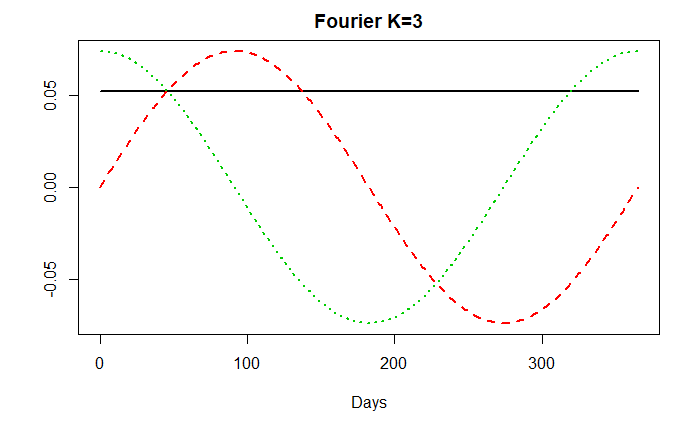

```r
plot(fourier_3, xlab = 'Days', main = 'Fourier K=3', lwd = 2)
```

Let’s now create and visualize a Fourier basis system with $K=5$ functions:

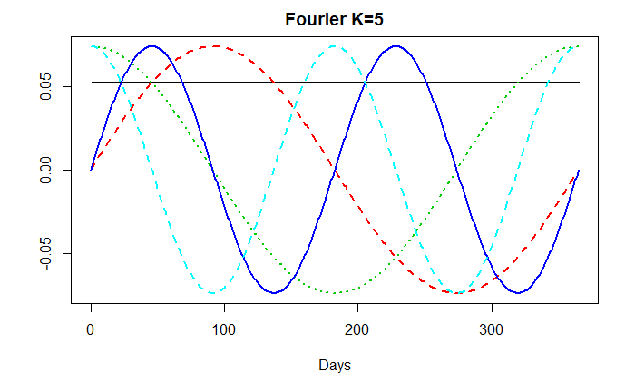

```r
fourier_5 = create.fourier.basis(range_day, nbasis = 5)

plot(fourier_5, xlab = 'Days', main = 'Fourier K=5', lwd = 2)
```

In addition to the 3 basis function we had before, we have sine and cosine with period $\frac{T}{2}$, i.e. $\phi_4(t)=\sin(2\omega t)$ and $\phi_5(t)=\cos(2\omega t)$.

### Spline basis

**Spline basis** are useful to model a non-periodic curve $x(t)$; we can try to use them for our temperature data if we ignore that temperature data are expected to be periodic. In order to create spline basis functions with equispaced knots, we employ the function `create.bspline.basis` from the package `fda`. This function wants as input the range for the values of $t$, the number of basis functions $K$ (argument `nbasis`), the order of the piecewise polynomial (argument `norder`, that is the degree of the polynomial plus 1, $d+1$). Note that, instead of specifying the number of functions $K$, we can specify directly the positions of the knots, providing a vector of positions using the argument `breaks` (we have `nbasis = nbreaks + norder - 2`, where `nbreaks` is the total number of knots).

Let’s create a spline basis system with degree $d=0$ (hence order 1) and breaks every 50 days, and visualize it using `plot`:

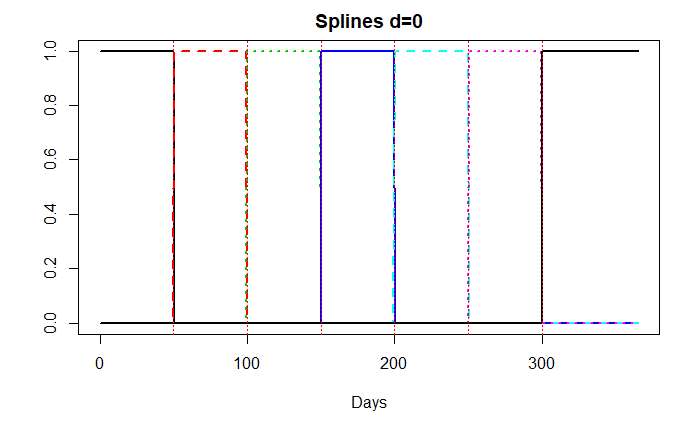

```r
breaks = seq(0, 365, by = 50)
spline_0 = create.bspline.basis(range_day, norder = 1, breaks = breaks)

plot(spline_0, xlab = 'Days', main = 'Splines d=0', lwd = 2)
```

Splines of degree $d=0$ are piecewise constant functions.

Let’s now create and visualize spline systems with degree $d=1$ (and same breaks):

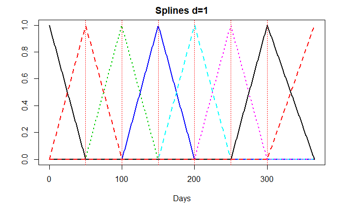

```r
breaks = seq(0, 365, by = 50)
spline_1 = create.bspline.basis(range_day, norder = 2, breaks = breaks)

plot(spline_1, xlab = 'Days', main = 'Splines d=1', lwd = 2)
```

And now a spline systems with degree $d=2$ (and same breaks):

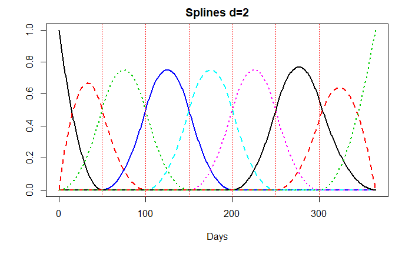

```r
breaks = seq(0, 365, by = 50)
spline_2 = create.bspline.basis(range_day, norder = 3, breaks = breaks)

plot(spline_2, xlab = 'Days', main = 'Splines d=2', lwd = 2)
```

Note that each of these basis functions is different from 0 only on some of the subintervals defined by the knots, hence spline basis are local (they don’t span the entire range of values of $t$).

## 3. Computing curves using regression splines

Let’s go back to consider the temperature data for Québec. We can use **regression splines** to estimate the coefficients $c_1,\dots,c_K$ and hence obtain the functional datum $x(t)=\sum_{k=1}^K c_k \phi_k(t)$. Note that we can use regression splines using different types of basis functions, not just spline basis… for exmaple, we can use it with Fourier basis functions!

In order to compute the curve $x(t)$ using regression splines, we can use the function `smooth.basis` from the package `fda`. In Session 10 we performed regression splines using a different package, but here we prefer to use the package `fda` because it is more general (different basis functions can be used) and specific for functional data analysis (it is easier to apply other FDA methods after creating the curves with this package). The function `smooth.basis` wants as input the vector of time points $t_j$ corresponding to the measurements, the corresponding noisy measurements $y_j$ and the object containing the basis functions $\phi_1, \dots, \phi_K$ we want to employ.

Let’s use regression splines on our Québec temperature data, using the Fourier basis with $K=3$ we created above:

```r
reg_fourier_3 = smooth.basis(daytime, temp_quebec, fourier_3)
```

The output is a list with many elements:

```r
names(reg_fourier_3)
```

```
[1] "fd"      "df"      "gcv"     "beta"    "SSE"     "penmat"  "y2cMap"  "argvals" "y"
```

We are interested in the first 3 elements:

- `fd`: object containing the fitted curve $x(t)$;
- `df`: the degrees of freedom used to define the fitted curve;
- `gcv`: the value of the generalized cross-validation criterion (that can be used to compare different set of basis functions).

Let’s visualize the fitted curve $x(t)$ over the raw data, using the function `plot` (`add = TRUE` is used to add the curve to the previous plot):

```
[1] "done"
```

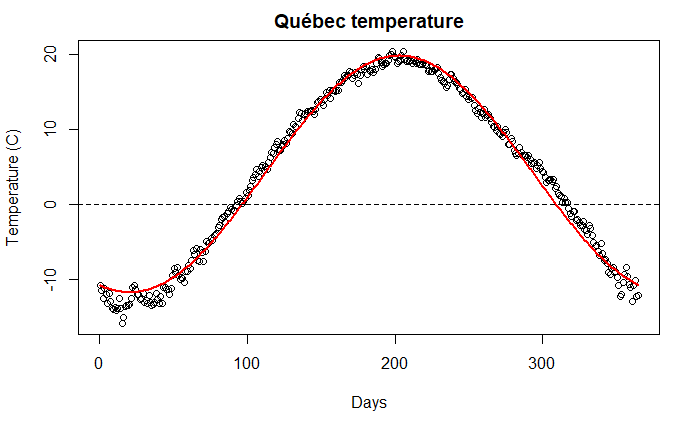

```r
plot(daytime, temp_quebec, xlab = 'Days', ylab = 'Temperature (C)', main = 'Québec temperature')
plot(reg_fourier_3$fd, col = 'red', lwd = 2, add = TRUE)
```

The curve seems to fit decently the data, but the minimum temperature in the Winter seems a bit overestimated and the decrease of temperature in the Fall seems a bit far from the points.

Let’s now try with the Fourier basis with $K=5$:

```
[1] "done"
```

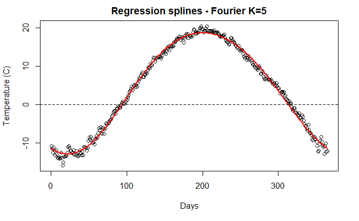

```r
reg_fourier_5 = smooth.basis(daytime, temp_quebec, fourier_5)

plot(daytime, temp_quebec, xlab = 'Days', ylab = 'Temperature (C)', main = 'Regression splines - Fourier K=5')
plot(reg_fourier_5$fd, col = 'red', lwd = 2, add = TRUE)
```

This fitted curve seems much better than the previous one.

We can use the generalized cross-validation values to compare the two fits:

```r
reg_fourier_3$gcv
```

```
    rep1
1.429797
```

```r
reg_fourier_5$gcv
```

```
     rep1
0.7290511
```

The GCV is indeed much smaller in the case of $K=5$, suggesting this fit is better.

We can also try different values of $K$ and choose the best one using GCV. Let’s try Fourier basis with $K=3,5,\dots,25$:

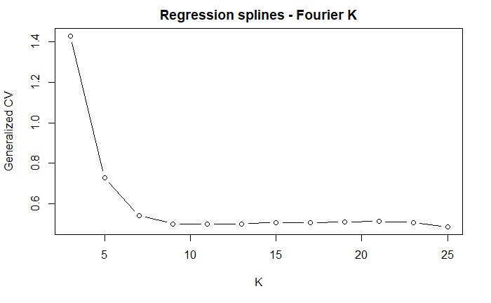

```r
K = seq(3, 25, by = 2)
GCV = vector('numeric', length(K)) # create an empty vector where to store GCV values

for(i in 1:length(K)){
  fourier_i = create.fourier.basis(range_day, nbasis = K[i])
  reg_fourier_i = smooth.basis(daytime, temp_quebec, fourier_i)
  GCV[i] = reg_fourier_i$gcv
}

plot(K, GCV, type = 'b', xlab = 'K', ylab = 'Generalized CV', main = 'Regression splines - Fourier K')
```

We don’t see a clear minimum GCV, but after $K=9$ the GCV doesn’t seem to change much. So we might want to use $K=9$ in this example:

```
[1] "done"
```

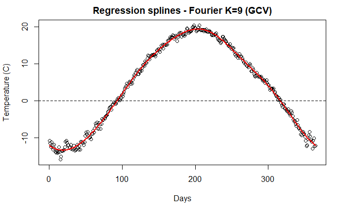

```r
fourier_9 = create.fourier.basis(range_day, nbasis = 9)
reg_fourier_9 = smooth.basis(daytime, temp_quebec, fourier_9)

plot(daytime, temp_quebec, xlab = 'Days', ylab = 'Temperature (C)', main = 'Regression splines - Fourier K=9 (GCV)')
plot(reg_fourier_9$fd, col = 'red', lwd = 2, add = TRUE)
```

Finally, note that we can employ the function `smooth.basis` directly on all the 35 locations in our datasets, in order to obtain all the corresponding curves $x_1(t),\dots,x_{35}(t)$ using regression splines with the same basis functions:

```
[1] "done"
```

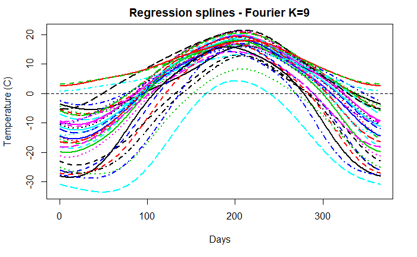

```r
reg_fourier_9_all_curves = smooth.basis(daytime, temp, fourier_9)

plot(reg_fourier_9_all_curves$fd, lwd = 2, xlab = 'Days', ylab = 'Temperature (C)', main = 'Regression splines - Fourier K=9')
```

## 4. Roughness penalty

Let’s now use **roughness penalty** to to estimate the coefficients $c_1,\dots,c_K$ and hence obtain the functional datum $x(t)=\sum_{k=1}^K c_k \phi_k(t)$. Note that we can use roughness penalty using different types of basis functions (splines, Fourier…).

In order to compute the curve $x(t)$ using roughness penalty splines, we can use again the function `smooth.basis` from the package `fda`. In Session 10 we perfomerd roughness penalty (smoothing splines) with a different function, that was able to fit only cubic ($d=3$) smoothing splines. The function `smooth.basis` is more general (different basis functions can be used) and specific for functional data analysis (it is easier to apply other FDA methods after creating the curves with this package).

In order to use the function `smooth.basis` for roughness penalty, we need to change the third input (it’s not the basis functions $\phi_1, \dots, \phi_K$ anymore). In particular, we need to provide as input the vector of time points $t_j$ corresponding to the measurements, the corresponding noisy measurements $y_j$ and an object specifying the basis functions $\phi_1, \dots, \phi_K$ *and the penalty we want to employ*.

Remember that roughness penalty finds the coefficients $c_1,\dots,c_K$ that minimize $RSS+\lambda PEN$, where $\lambda$ is the smoothing tuning parameter and the penalty term considers the second derivative of the curve, i.e.
$$PEN = \int{x''(t) dt} = \int{ \left( c_1 \phi_1''(t) + \cdots + c_K \phi_K''(t) \right)^2 dt}$$
In order to create this penalty we can use the function `fdPar`, giving as input the basis functions $\phi_1, \dots, \phi_K$, the order of the derivative we want to penalize (in our case 2) and the value of the tuning parameter $\lambda$. Remember that, in general, with roughness penalty we employ a very rich basis system (with a large number of functions $K$) and we impose smoothness through the tuning parameter $\lambda$ (the larger the $\lambda$, the smoother the curve will be).

Let’s use rough splines on our Québec temperature data, using a Fourier basis with $K=65$, penalty on the second derivative and $\lambda=1$:

```r
fourier_65 = create.fourier.basis(range_day, nbasis = 65)
fdPar_fourier_lambda_1 = fdPar(fourier_65, 2, lambda = 1)
```

We can now use roughness penalty to fit the curve:

```r
rough_fourier_lambda_1 = smooth.basis(daytime, temp_quebec, fdPar_fourier_lambda_1)
```

Let’s visualize the fitted curve $x(t)$ over the raw data, using the function `plot` (`add = TRUE` is used to add the curve to the previous plot):

```
[1] "done"
```

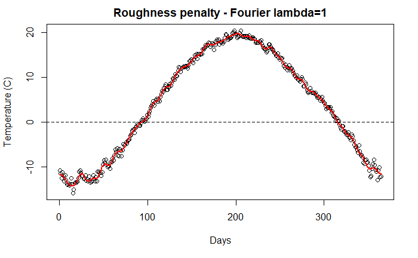

```r
plot(daytime, temp_quebec, xlab = 'Days', ylab = 'Temperature (C)', main = 'Roughness penalty - Fourier lambda=1')
plot(rough_fourier_lambda_1$fd, col = 'red', lwd = 2, add = TRUE)
```

The fitted curve seems to overfit the data!

Let’s try to increase the value of $\lambda$ in order to obtain a smoother curve. For example, let’s try a very large parameter $\lambda=1000$:

```
[1] "done"
```

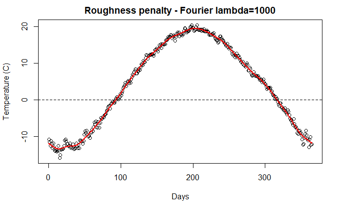

```r
fdPar_fourier_lambda_1000 = fdPar(fourier_65, 2, lambda = 1000)
rough_fourier_lambda_1000 = smooth.basis(daytime, temp_quebec, fdPar_fourier_lambda_1000)

plot(daytime, temp_quebec, xlab = 'Days', ylab = 'Temperature (C)', main = 'Roughness penalty - Fourier lambda=1000')
plot(rough_fourier_lambda_1000$fd, col = 'red', lwd = 2, add = TRUE)
```

The result in this case is very smooth and maybe we are missing some of the small patterns in the curves.

Let’s compare the generalized cross-validation values of the two fits:

```r
rough_fourier_lambda_1$gcv
```

```
     rep1
0.4013252
```

```r
rough_fourier_lambda_1000$gcv
```

```
     rep1
0.4551347
```

The GCV is actually smaller in the case of $\lambda=1$, suggesting this fit is better.

We can try different values of the tuning parameter $\lambda$ and choose the best one using GCV. Let’s try Fourier basis with $K=65$ and $\lambda$ between $10^{-4}$ and $10^4$:

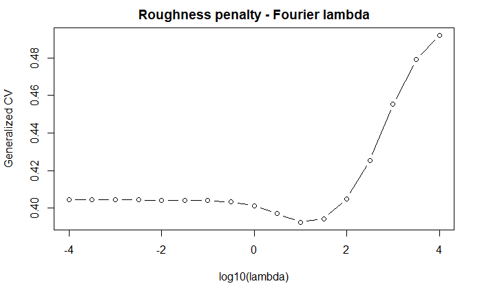

```r
lambda = 10^seq(-4, 4, by = 0.5)
GCV = vector('numeric', length(lambda)) # create an empty vector where to store GCV values

for(i in 1:length(lambda)){
  fdPar_fourier_lambda_i = fdPar(fourier_65, 2, lambda = lambda[i])
  rough_fourier_lambda_i = smooth.basis(daytime, temp_quebec, fdPar_fourier_lambda_i)
  GCV[i] = rough_fourier_lambda_i$gcv
}

plot(log10(lambda), GCV, type = 'b', xlab = 'log10(lambda)', ylab = 'Generalized CV', main = 'Roughness penalty - Fourier lambda')
```

The minimum GCV is suggesting to use $\log_{10} \lambda=1$, i.e. $\lambda = 10$:

```
[1] "done"
```

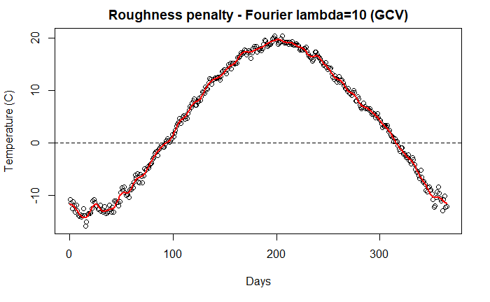

```r
fdPar_fourier_lambda_10 = fdPar(fourier_65, 2, lambda = 10)
rough_fourier_lambda_10 = smooth.basis(daytime, temp_quebec, fdPar_fourier_lambda_10)

plot(daytime, temp_quebec, xlab = 'Days', ylab = 'Temperature (C)', main = 'Roughness penalty - Fourier lambda=10 (GCV)')
plot(rough_fourier_lambda_10$fd, col = 'red', lwd = 2, add = TRUE)
```

Also in this case we can employ the function `smooth.basis` directly on all the 35 locations in our datasets, in order to obtain all the corresponding curves $x_1(t),\dots,x_{35}(t)$ using roughness penalty with the same basis functions, penalty and $\lambda$:

```
[1] "done"
```

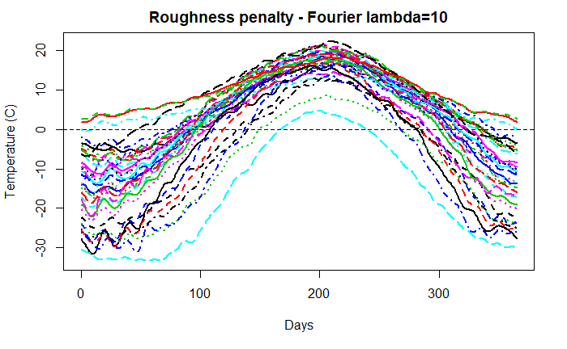

```r
rough_fourier_lambda_10_all_curves = smooth.basis(daytime, temp, fdPar_fourier_lambda_10)

plot(rough_fourier_lambda_10_all_curves$fd, lwd = 2, xlab = 'Days', ylab = 'Temperature (C)', main = 'Roughness penalty - Fourier lambda=10')
```